# MASZ - Projekt 7 Probabilistyczne aspekty sieci złożonych

Ryszard Szymański

5/3/2020

# Zadania wykładowe

## Zadanie 4

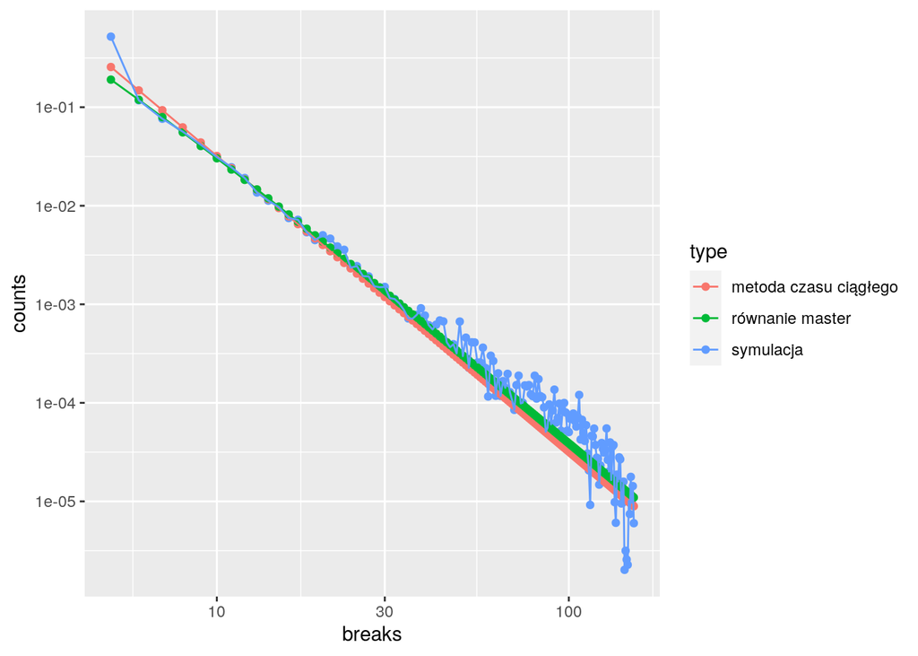

```r
ba_graph_large <- drake::readd(ba_graph_large)

calculate_mean_degrees_hist <- function(graphs) {
  step_degrees_list <- graphs %>%  lapply(degree)

  breaks <- step_degrees_list %>% unlist() %>% unique() %>% sort()
  mean_degrees_hist <- lapply(step_degrees_list, function(degrees) {
    hist_vals <- hist(degrees, breaks = breaks, plot = F)
    data.frame(breaks = hist_vals$breaks[-1], counts = hist_vals$density)
  }) %>% bind_rows() %>%
    group_by(breaks) %>%
    summarise(counts = mean(counts))
}

mean_degrees_hist <- calculate_mean_degrees_hist(ba_graph_large$steps)
k <- 4
get_theoretical_results <- function(k, m) {
  (2 * k^2) / m^3
}
get_masters_equation_results <- function(k, m) {
  (2 * m * (m + 1)) / (k * (k + 1) * (k + 2))
}

mean_degrees_hist$type <- "symulacja"
continuous_time_method_results <- data.frame(
  breaks = mean_degrees_hist$breaks,
  counts = get_theoretical_results(k, mean_degrees_hist$breaks),
  type = "metoda czasu ciągłego"
)
masters_equation_results <- data.frame(
  breaks = mean_degrees_hist$breaks,
  counts = get_masters_equation_results(mean_degrees_hist$breaks, k),
  type = "równanie master"
)

all_vals <- bind_rows(mean_degrees_hist, continuous_time_method_results, masters_equation_results)
all_vals %>%
  ggplot(aes(x = breaks, y = counts, color = type, group = type)) +
  geom_point() +
  geom_line() +
  scale_x_log10() +
  scale_y_log10()
```

Na podstawie wykresu trudno określić, które rozwiązanie lepiej dopasowuje się do rozkładu empirycznego.

## Zadanie 5

W celu weryfikacji, które podejście lepiej się dopasowuje do rozkładu empirycznego zastosowano test Kołmogorowa-Smirnowa. Poniżej przedstawiono wyniki:

```r
empirical_values <- all_vals %>% filter(type == "symulacja") %>% pull(counts)
continuous_time_method <- all_vals %>% filter(type == "metoda czasu ciągłego") %>% pull(counts)
master_values <- all_vals %>% filter(type == "równanie master") %>% pull(counts)

data.frame(
  "Metoda czasu ciągłego" = ks.test(empirical_values, continuous_time_method)$p.value,
  "Równanie master" = ks.test(empirical_values, master_values)$p.value
) %>% knitr::kable()
```

| Metoda.czasu.ciągłego | Równanie.master |
| --- | --- |
| 0.0214128 | 0.1364585 |

Uzyskana $p$-wartość jest wyższa dla równania master, stąd można stwierdzić, że lepiej się on dopasowuje do rozkladu empirycznego.

## Zadanie 12

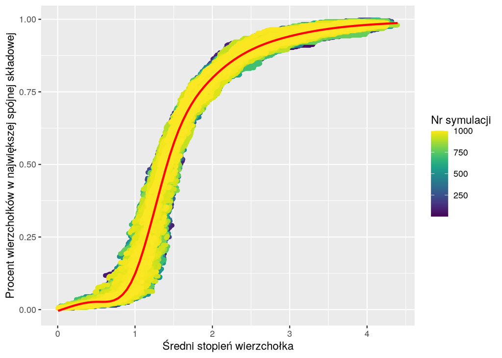

```r
drake::readd(simulation_results_plot)
```

## Zadanie 20

# Zadania 24-25

W celu porównania odporności sieci ER oraz sieci bezskalowych na awarie przeprowadzono symulacje składające się z 1000 iteracji. W trakcie każdej iteracji usuwano losowo wierzchołki rozpatrując różne wartości prawdopodobieństwa awarii (100 wartości od 0 do 1). Wyniki pogrupowano po prawdopodobieństwach i zagregowano w postaci średniej.

W celu zapewnienia obiektywnego porównania, generowano sieci w taki sposób, żeby miały tyle samo wierzchołków oraz miały taką samą gęstość. Procedura zaczyna się od wygenerowania/wczytania sieci bezskalowej i następnie wygenerowania sieci ER za pomocą modelu $G_{N,E}$.

## Porównanie sieci ER i BA pod względem losowych awarii

W trakcie pierwszej symulacji porównano sieci ER oraz sieci BA pod względem odporności na awarie. Uzyskane wyniki przedstawiono na poniższym wykresie:

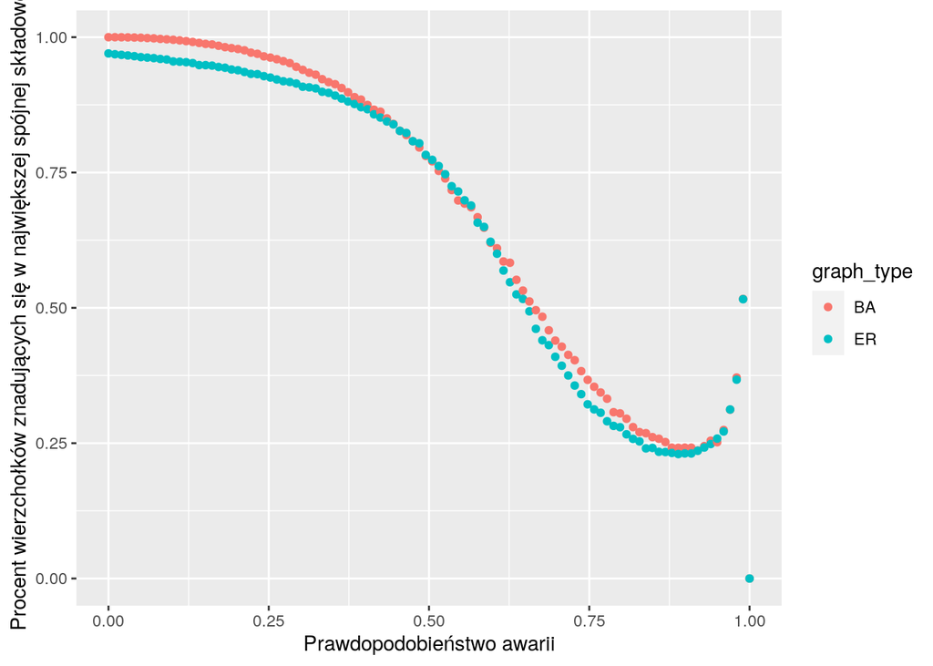

```r
drake::readd(project_simulation_random_vertices_plot) +
  labs(x = "Prawdopodobieństwo awarii", y = "Procent wierzchołków znadujących się w największej spójnej składowej")
```

Między odpornością obu sieci widoczne są niewielki różnice. Wynik jest o tyle zaskakujący, że raczej spodziewana jest sytuacja, w której sieci BA jako sieci bezskalowe są bardziej odporne na losowe awarie niż sieci ER. Jednak w [Network Science](http://networksciencebook.com/chapter/8#robustness) wykazano, że sieci bezskalowe, których współczynnik $\alpha > 3$ zachowują się jak sieci losowe a współczynnik $\alpha$ dla sieci BA jest zbliżony do $3$.

## Porównanie sieci ER i sieci rzeczywistej pod względem losowych awarii

Jako przykładową sieć bezskalową ze współczynnikim $\alpha < 3$ wykorzystano dane mailowe z [Network Science](http://networksciencebook.com/translations/en/resources/data.html). Wygenerowano sieć ER o zgodnie z opisaną wcześniej procedurą. Wyniki przedstawiono na nastęþującym wykresie:

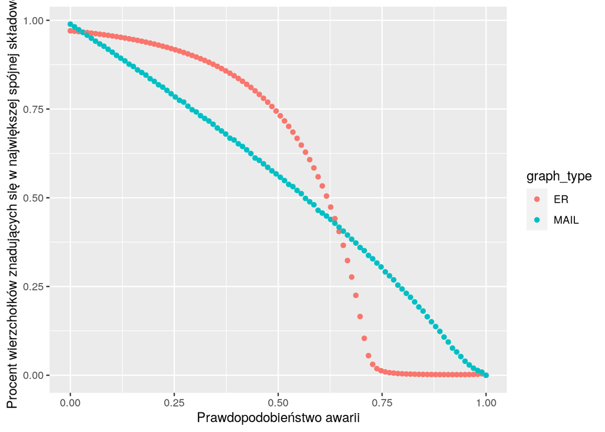

```r
drake::readd(project_simulation_random_vertices_real_plot) +
  labs(x = "Prawdopodobieństwo awarii", y = "Procent wierzchołków znadujących się w największej spójnej składowej")
```

Można zauważyć, że z początku sieć ER była bardziej odporna. W ostatniej ćwiartce wykresu można zaobserwować, że sieć ER się już całkowicie rozpada podczas gdy sieć rzeczywista jeszcze zachowuje pewien poziom spójności.

## Porównanie sieci ER i BA pod względem intencjonalnych ataków

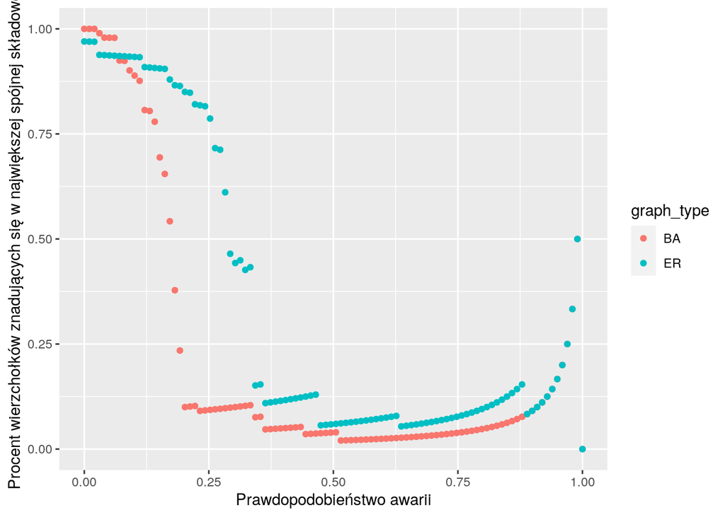

```r
drake::readd(project_simulation_attack_vertices_plot) +
  labs(x = "Prawdopodobieństwo awarii", y = "Procent wierzchołków znadujących się w największej spójnej składowej")
```

Sieci BA są mniej odporne na intencjonalne ataki.